# Transforming Probability Spaces

Author

Michael Betancourt

Published

December 2023

All probability theory chapters can be found [here](http://www.symplectomorphic.com/writing/#part1).

A repository containing all of the files used to generate this chapter is available on [GitHub](https://github.com/betanalpha/quarto_chapters/tree/main/7_transforming_probability_spaces).

We learned how basic structures, such as metrics and topologies, are modified when we transform the ambient set in In [Chapter 2](http://www.symplectomorphic.com/assets/chapters_html/spaces.html). In this chapter, we’ll learn how measure-theoretic structures are transformed, including probability distributions, expectation values, and probability density functions.

# 1 Transforming $\sigma$-Algebras

We’ve already seen how to transform subsets in [Chapter 2](http://www.symplectomorphic.com/assets/chapters_html/spaces.html). Given two spaces $X$ and $Y$ and any function $f : X \rightarrow Y$, we can always push subsets in $X$ forward to subsets in $Y$ by combining the output of each point in the input subset (Figure 1 (a)),
$$\begin{alignat*}{6}
f_{*} :\; & 2^{X} & &\rightarrow& \; & 2^{Y} &
\\
& \mathsf{x} & &\mapsto& &
f_{*} \mathsf{x} = \{ f(x) \mid x \in \mathsf{x} \} &.
\end{alignat*}$$
Similarly, we can pull subsets in $Y$ back to subsets in $X$ by combining the preimages of every output point (Figure 1 (b)),
$$\begin{alignat*}{6}
f^{*} :\; & 2^{Y} & &\rightarrow& \; & 2^{X} &
\\
& \mathsf{y} & &\mapsto& &
\phi^{*} \mathsf{y} = \{ x \in X \mid f(x) \in \mathsf{y} \} &.
\end{alignat*}$$

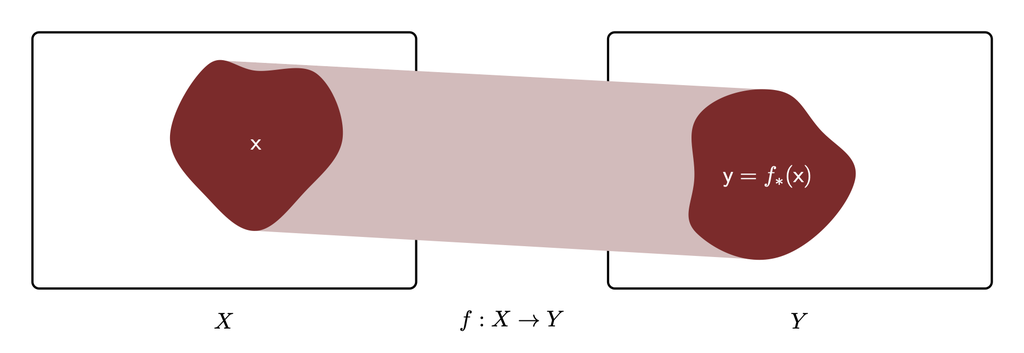

(a)

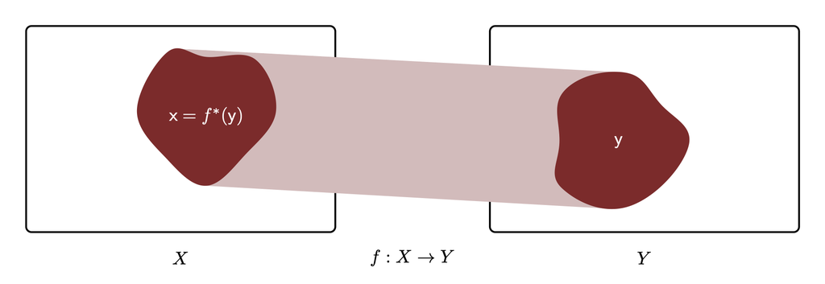

(b)

Figure 1: Transformations of a set induce transformations of subsets. (a) Subsets of the input space $\mathsf{x} \subset X$ can be pushed forward into subsets of the output space, $f_{*}(\mathsf{x}) \subset Y$. (b) Similarly, subsets of the output space $\mathsf{y} \subset Y$ can be pulled back into subsets of the input space, $f^{*}(\mathsf{y})\subset X$.

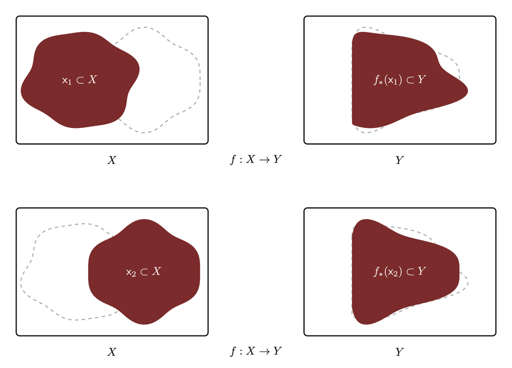

(a)

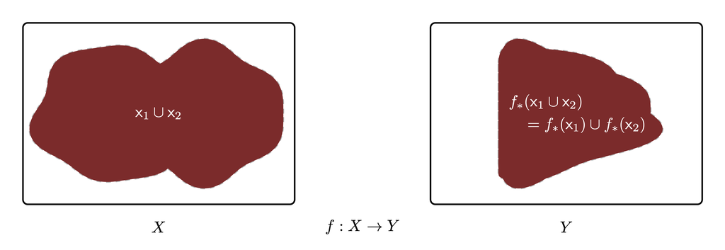

(b)

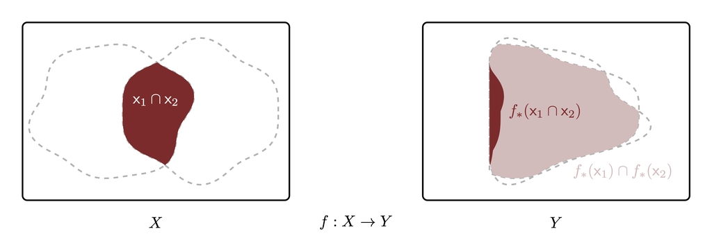

(c)

This has an immediate consequence for $\sigma$-algebras: the pushforward of the intersection of measurable input subsets isn’t necessarily a measurable output subset. Consequently, a $\sigma$-algebra of measurable subsets on $X$ doesn’t always push forward into a $\sigma$-algebra of measurable subsets on $Y$.

On the other hand, a $\sigma$-algebra on $Y$ *does* always pull back to a well-behaved $\sigma$-algebra on $X$. If $\mathcal{Y}$ is a $\sigma$-algebra on $Y$, then
$$f^{*} \mathcal{Y} =
\{ f^{*}(\mathsf{y}) \mid \mathsf{y} \in \mathcal{Y} \}$$
is referred to as the **pullback $\sigma$-algebra along $f$**, or the **$\sigma$-algebra generated by $f$**.

In order for a function $f: X \rightarrow Y$ to preserve the structure of two measurable spaces $(X, \mathcal{X})$ and $(Y, \mathcal{Y})$, every measurable subset $\mathsf{y} \in \mathcal{Y}$ needs to pull back to a measurable subset in $\mathcal{X}$,
$$f^{*}(\mathsf{y}) \in \mathcal{X},$$
Equivalently, $f$ preserves measurable structure only when
$$f^{*} \mathcal{Y} \subseteq \mathcal{X}.$$
Note that this does not require that *every* measurable subset $\mathsf{x} \in \mathcal{X}$ pushes forward to a measurable subset in $\mathcal{Y}$; we can safely ignore some measurable input subsets without compromising the $\sigma$-algebra on the output space.

Functions that preserve measurable structure are known as **$(\mathcal{X}, \mathcal{Y})$-measurable functions**. When the $\sigma$-algebras on the input and output space are unambiguous, this is often shortened to just **measurable functions**. I will also use the more compact notation
$$f : (X, \mathcal{X}) \rightarrow (Y, \mathcal{Y})$$
to denote $(\mathcal{X}, \mathcal{Y})$-measurable functions.

We’ve already encountered measurable functions in [Chapter 5](http://www.symplectomorphic.com/assets/chapters_html/expectation_values.html) when I introduced measure-informed integration. A real-valued function $f : X \rightarrow \mathbb{R}$ can be integrated on the measure space $(X, \mathcal{X}, \mu)$ if every half-open interval on the output space pulls back to a measurable subset on the input space,
$$f^{*}( \, (-\infty, x) \, ) \in \mathcal{X}.$$
This condition, however, is equivalent to every subset in the Borel $\sigma$-algebra of the real line, $\mathsf{y} \in \mathcal{B}_{\mathbb{R}}$, pulling back to a measurable subset on the input space,
$$f^{*}( \mathsf{y} ) \in \mathcal{X}.$$

In other words, what we referred to as “$\mathcal{X}$-measurable real-valued functions” in [Chapter 5](http://www.symplectomorphic.com/assets/chapters_html/expectation_values.html) are more formally $(\mathcal{X}, \mathcal{B}_{\mathbb{R}})$-measurable functions. The former notation takes the Borel $\sigma$-algebra on the real line for granted, while the latter makes it more explicit. This is a common shorthand – references to “measurable functions” without any specification almost always imply Borel $\sigma$-algebras on the input and output spaces.

Fortunately, this shorthand isn’t too problematic in practice because we will almost always be working with measures defined over Borel $\sigma$-algebras derived from the topological structure of the relevant spaces. Consequently, a function $f : X \rightarrow Y$ mapping the Borel measurable space $(X, \mathcal{B}_{X})$ into the Borel measurable space $(Y, \mathcal{B}_{Y})$ might be described as $(\mathcal{B}_{X}, \mathcal{B}_{Y})$-measurable, **Borel measurable**, or even just “measurable”.

Continuous functions that respect the topological structure of the input and outputs spaces are always Borel measurable, but so too are functions that are only piece-wise continuous. Ultimately, Borel measurability is a much weaker condition than topological continuity; we can map open subsets in the output space into not only open subsets in the output space, but also closed subsets in the output space, and even any subset that we can derive from unions and intersections of open and closed subsets in the input space.

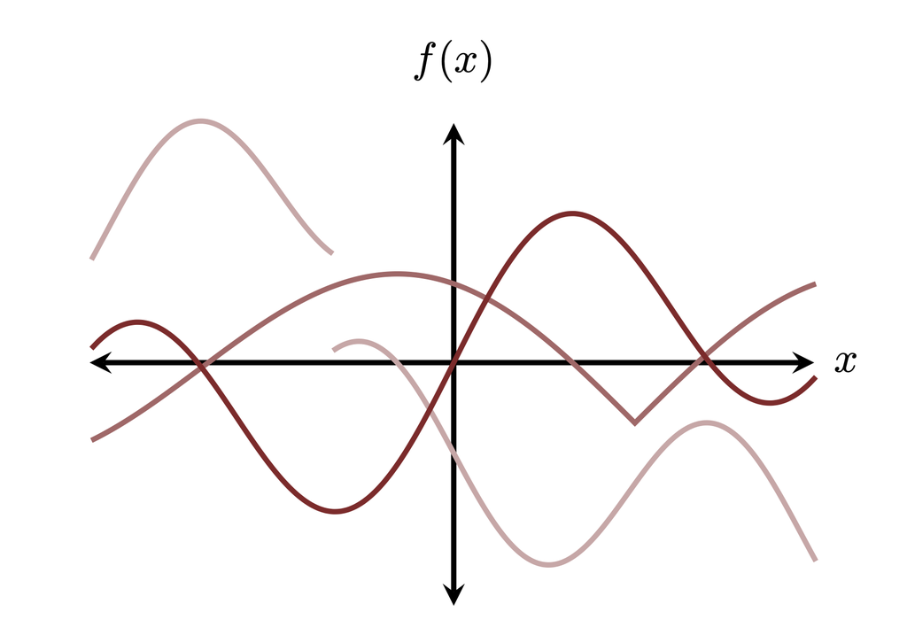

Figure 3: Most of the functions that we encounter in practice are measurable with respect to the standard $\sigma$-algebras. For example, functions $f: \mathbb{R} \rightarrow \mathbb{R}$ that are smooth, non-differentiable but continuous, and even discontinuous at a countable number of points are all $(\mathcal{B}_{\mathbb{R}}, \mathcal{B}_{\mathbb{R}})$-measurable.

When working with finite-dimensional spaces in practice, it is safe to assume that not only all but the most pathological subsets are measurable, but also that all but the most pathological functions are measurable. Infinite-dimensional spaces are another matter, but those spaces will largely be outside of the scope of this book.

# 2 Transforming Measures

Conveniently, the pullback of measurable subsets allows us to pushforward measures from the input space to a compatible measure on the output space. Given a $(\mathcal{X}, \mathcal{Y})$-measurable function $f : X \rightarrow Y$, any measure $\mu : \mathcal{X} \rightarrow [0, \infty]$ defines a **pushforward measure** by the allocations
$$\begin{alignat*}{6}
f_{*} \mu :\; & \mathcal{Y} & &\rightarrow& \; & \mathbb{R}^{+} &
\\
& \mathsf{y} & &\mapsto& &
f_{*} \mu (\mathsf{y}) = \mu(f^{*}(\mathsf{y})) &.
\end{alignat*}$$
In words, the pushforward measure allocated to any measurable subset on the output space $\mathsf{y} \in \mathcal{Y}$ is computed by pulling the subset back to the input space, $f^{*}(\mathsf{y}) \in \mathcal{X}$, and then evaluating the initial measure, $\mu(f^{*}(\mathsf{y}))$ (Figure 4).

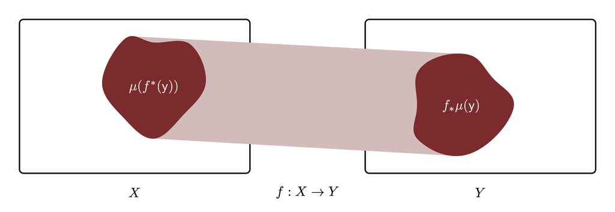

Figure 4: Because measurable output subsets pull back to measurable input subsets along measurable functions, we can push forward measure allocations. In particular, the pushforward measure allocated to the measurable output subset $\mathsf{y} \in \mathcal{Y}$ is given by pulling it back to the input space, $f^{*}(\mathsf{y}) \in \mathcal{X}$, and then querying the initial measure, $\mu(f^{*}(\mathsf{y}))$.

The exact interpretation of a pushforward measure will depend on the interpretation of the input measure and the transformation. Consider, for example, a probability distribution $\pi$ defined on the input space that we interpret as quantifying uncertainty. This probability distribution captures our uncertainty about the *inputs* to a function $f$, while the pushforward probability distribution $f_{*} \pi$ quantifies the corresponding uncertainty in the *output* of the function. In other words, the pushforward transformation *propagates* the initial uncertainty through the deterministic mapping.

At the same time, certain transformations can endow their corresponding pushforward measures with particular interpretations.

## 2.1 Pushforward Terminology

Pushforward measures are ubiquitous in applied probability theory, although they are often better known by other names.

Consider, for example, a finite input space $X$,
$$X = \{ \blacksquare, \clubsuit, \bigcirc,
\diamondsuit, \triangle, \bowtie \},$$
a finite output space $Y$,
$$Y = \{ \heartsuit, \spadesuit, \bigstar \},$$
and a function $f : X \rightarrow Y$ defined by the relations (Figure 5 (a))
$$\begin{align*}
f(\blacksquare) &= \spadesuit
\\
f(\clubsuit) &= \heartsuit
\\
f(\bigcirc) &= \bigstar
\\
f(\diamondsuit) &= \spadesuit
\\
f(\triangle) &= \heartsuit
\\
f(\bowtie) &= \spadesuit
\end{align*}$$

These relationships between input and output points become particularly well-organized when we arrange the input elements into a table, with each row collecting all of the input elements that map to a particular output element (Figure 5 (b)). Conveniently, the pushforward measure allocated to each output atomic subset is then given by summing the input atomic subset allocations in each the corresponding rows (Figure 5 (c), Figure 5 (c)). In other words, the pushforward allocations fit nicely into the *margins* of the table.

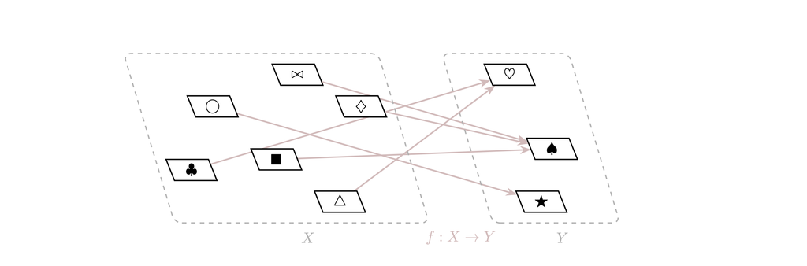

(a)

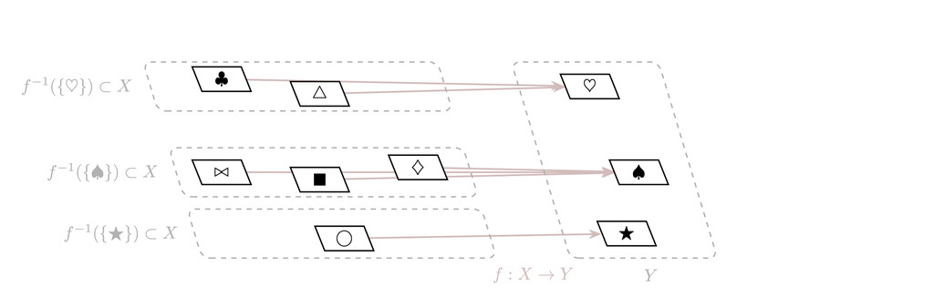

(b)

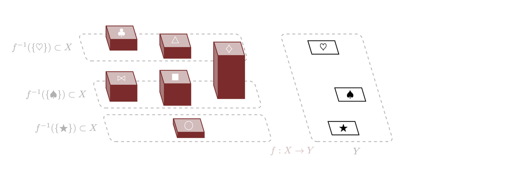

(c)

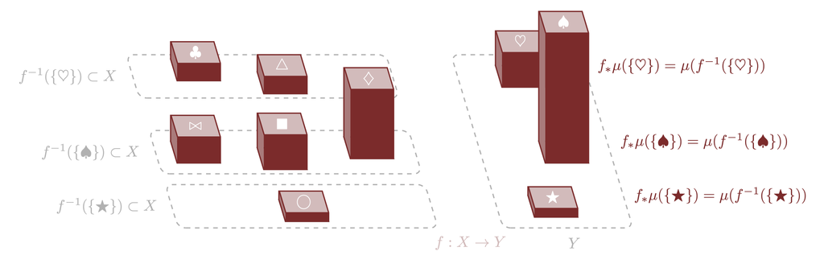

(d)

Figure 5: On finite spaces (a) functions $f: X \rightarrow Y$ (b) are naturally organized into tables, with each row collecting all of the input points that map to each output point. (c) Given an input measure $\mu$, (d) we can compute the pushforward measure allocations by summing the $\mu$ allocations in each row and then displaying the results in the margins of the table.

Historically, this kinds of graphical organization motivated the term **marginal measure** to describe pushforward measures, or **marginal probability distribution** in the case of an input probability distribution. Today this terminology is common even when the input and output spaces are not finite, and the tabular representation of functions isn’t quite as useful (Figure 6).

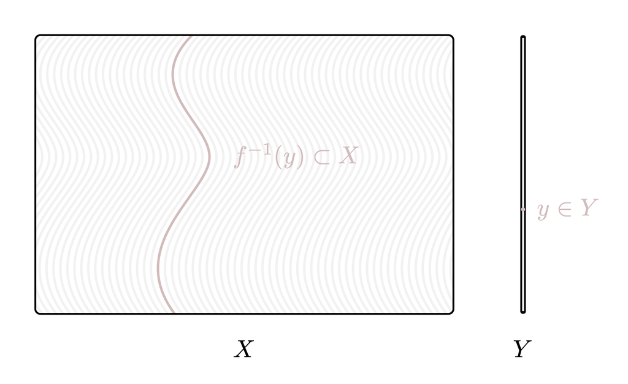

(a)

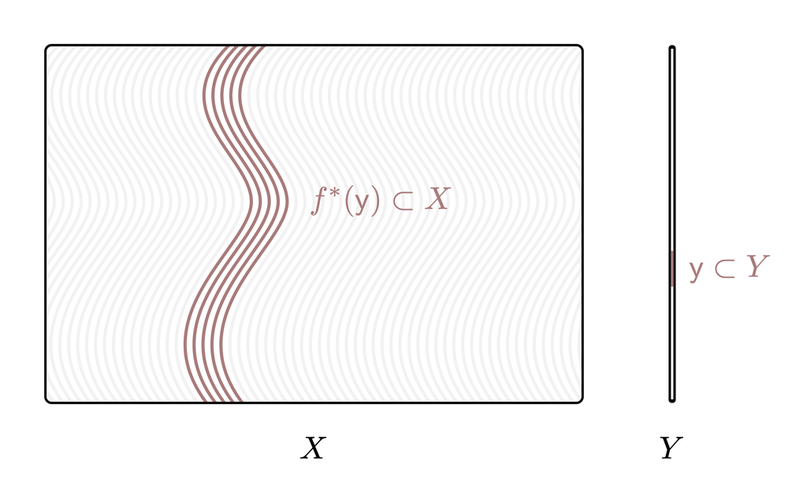

(b)

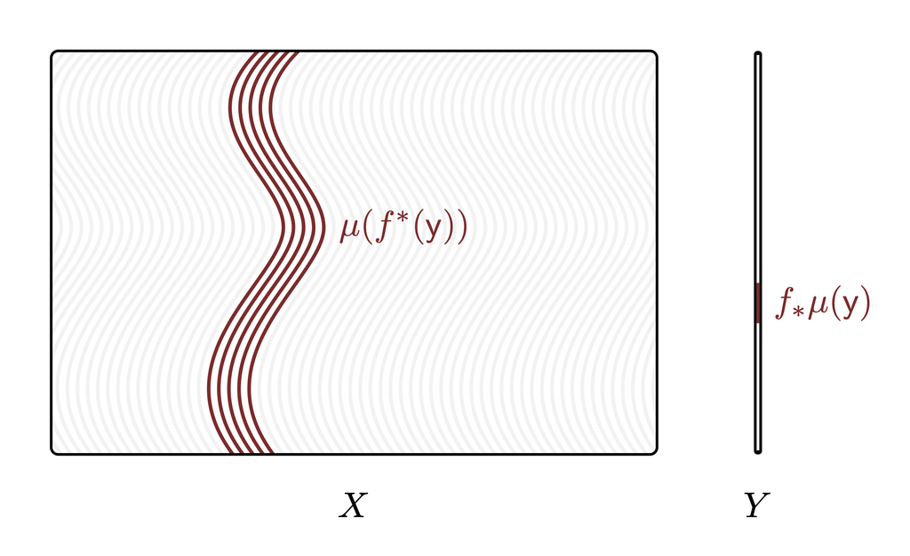

(c)

Figure 6: When working on general spaces, the tabular organization of a function $f: X \rightarrow Y$ generalizes to (a) collections of level sets $f^{-1}(y) \subset X$, one for each output point $y \in Y$. (b) The pullback of any output subset is the union of these level sets, and (c) the pushforward measure allocated to any output subset is effectively the sum of the measures allocated to the relevant level sets. These pushforward allocations can then be informally collected into the “margins”.

Another popular naming convention arises when the output space is a subset of the input space, $Y \subset X$. In this case, a function $f: X \rightarrow Y$ **projects** the input space onto the output subset (Figure 7). Pushing measures forward along this projection *collapses* the total measure allocated to the input space into the smaller output space.

[figure not shown]

(a)

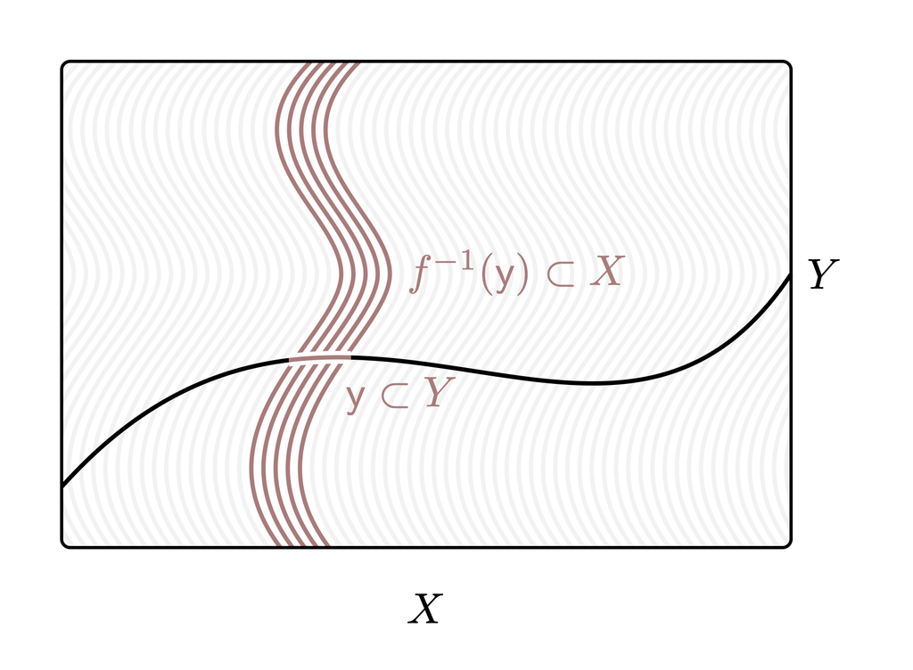

(b)

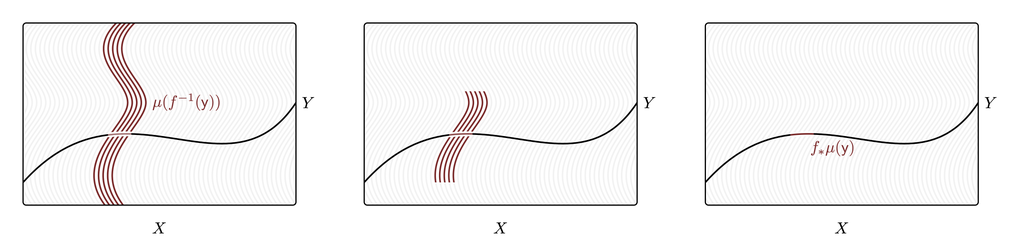

(c)

Figure 7: When a function $f: X \rightarrow Y$ maps an input space into a subset of itself, $Y \subset X$, pushforward measures can be interpreted as projections of the initial measure. (a) In this case, each level set $f^{-1}(y)$ is anchored to a point $y \in X$ and (b) the pullback of an output subset is anchored to the points in that subset. (c) The pushforward measure collapses the measure allocated to each level set down to the corresponding anchor point.

Consider for instance, the unit interval interpreted as a subset of a real line,
$$(0, 1) \subset R.$$
One way to squeeze the entire real line into $(0, 1)$ is to apply the **logistic function**,
$$\begin{alignat*}{6}
\mathrm{logistic} :\; & \mathbb{R} & &\rightarrow& \; & (0, 1) &
\\
& x & &\mapsto& & \frac{1}{1 + \exp(-x)} &.
\end{alignat*}$$

The logistic function preserves topological structure, pushing open intervals in $\mathbb{R}$ forward into open intervals in $(0, 1)$,
$$\mathrm{logistic}_{*}( \, (x_{1}, x_{2}) \, )
=
( \, \mathrm{logistic}(x_{1}), \mathrm{logistic}(x_{2}) \, ).$$
At the same time, open intervals in $(0, 1)$ are pulled back into open intervals in $\mathbb{R}$,
$$\mathrm{logistic}^{*}( \, (y_{1}, y_{2}) \, )
=
( \, \mathrm{logistic}^{-1}(y_{1}),
\mathrm{logistic}^{-1}(y_{2}) \, ).$$
Consequently, the logistic function is Borel measurable.

When pushing measures forward along the logistic function, the measure allocated to any open interval is squeezed into a narrower interval,
$$\begin{align*}
\mu_{*}( \, (y_{1}, y_{2}) \, )
&=
\mu( \, \mathrm{logistic}^{*}( \, (y_{1}, y_{2}) \, ) \, )
\\
&=
\mu( \, (\, \mathrm{logistic}^{-1}(y_{1}),
\mathrm{logistic}^{-1}(y_{2}) \, ) \, ).
\end{align*}$$

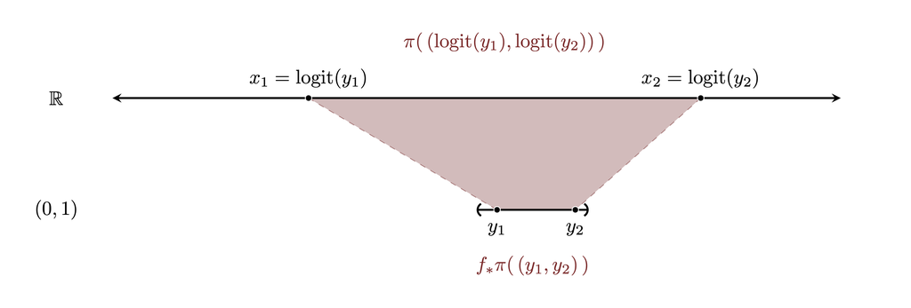

Figure 8: The logistic function squeeze an entire real line into a unit interval. When we push an input measure forward along the logistic function, the measure allocated to an input interval is squeezed into a narrower interval.

## 2.2 Lossy Pushforward Measures

We can always push measures forward along measurable functions, but in general we cannot pull them back. This asymmetry arises because the pushforward operation can *lose information*.

Consider the function between finite spaces that we introduced in Section 2.1. A measure $\mu$ on the input space defines the pushforward atomic allocation
$$\begin{align*}
f_{*} \mu( \{ \heartsuit \} )
&=
\mu( f^{*}(\heartsuit) )
\\
&=
\mu( \{ \clubsuit, \triangle \} )
\\
&=
\mu( \{ \clubsuit \} ) + \mu( \{ \triangle \} ).
\end{align*}$$
Because the input elements $\clubsuit$ and $\triangle$ both map to the same output element, their atomic allocations are combined into a single pushforward atomic allocation.

If we are given only the pushforward allocation $f_{*} \mu( \{ \heartsuit \} )$, then we will not have enough information to fully recover the initial allocations $\mu( \{ \triangle \} )$ and $\mu( \{ \triangle \} )$. We can constrain their sum,
$$f_{*} \mu( \{ \heartsuit \} )
=
\mu( \{ \clubsuit \} ) + \mu( \{ \triangle \} ),$$
but there are infinitely many input measures consistent with such a constraint.

For a more sophisticated example, let’s investigate a function that maps a real line into integers by rounding each real number to the next largest integer,
$$\begin{alignat*}{6}
f :\; & \mathbb{R} & &\rightarrow& \; & \mathbb{Z} &
\\
& x & &\mapsto& & \lceil x \rceil &.
\end{alignat*}$$
This function collapses every point in the half-open interval $(n - 1, n]$ to the integer $n$, and the atomic subsets on the output space pull back to those input intervals (Figure 9),
$$f^{*}( \{ n \} ) = (n - 1, n].$$

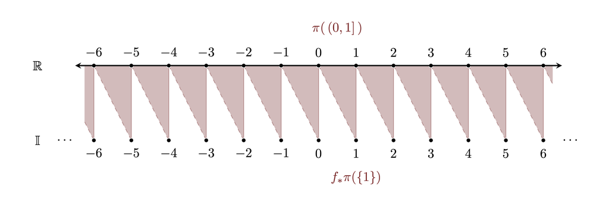

Figure 9: Rounding real numbers to the next-largest integer defines a map from a real line to the integers. The input measure allocated to the half-open interval $(n - 1, n]$ projects down to the corresponding integer $n$.

The Lebesgue measure on the input real line pushes forward along $f$ to a measure on the integers with the atomic allocations
$$\begin{align*}
f_{*} \lambda( \{ n \} )
&=
\lambda( f^{*} ( \{ n \} ) )
\\
&=
\lambda( \, (n, n - 1] \, )
\\
&=
n - (n - 1)
\\
&=
1.
\end{align*}$$
In other words, the pushforward of the Lebesgue measure along this rounding map is just the counting measure!

That said, the counting measure on the output space does not provide any information about how to distribute the atomic allocation $\chi( \{ n \} ) = 1$ across the entire pullback subset $(n - 1, n]$. Instead, there are infinitely many ways that the measure $\chi( \{ n \} ) = 1$ could be consistently reallocated across $(n - 1, n]$, and we have no criteria for preferring one over another.

## 2.3 Lossless Pushforward Measures

Because most pushforward measures lose information about the initial allocations, the exceptional measures that preserve information are particularly notable.

As we saw in Section 1, pushforward sets do not generally respect the intersection set operator, preventing us from pushing $\sigma$-algebras forward from the input space to the output space. Pushing sets forward along injective functions, however, does respect the intersection operator. Consequently, we can always push $\sigma$-algebras forward along injective functions.

When working with measurable spaces that are already equipped with $\sigma$-algebras, $(X, \mathcal{X})$ and $(Y, \mathcal{Y})$, any injective function $f : X \rightarrow Y$ that both pulls measurable output subsets back to measurable input subsets,
$$f^{*}(\mathsf{y}) \subset \mathcal{X},$$
*and* pushes measurable input subsets forward to measurable output subsets,
$$f_{*}(\mathsf{x}) \subset \mathcal{Y}.$$
is said to be **$( \mathcal{X}, \mathcal{Y} )$-bimeasurable**, or simply **bimeasurable** when the $\sigma$-algebras are unambiguous.

Because the pushforward and pullback maps along any injective function always satisfy
$$f^{*} \circ f_{*} = I,$$
we also have
$$f^{*}(\mathcal{Y}) = \mathcal{X}.$$
In other words, the $\sigma$-algebra generated by a bimeasurable function is just the input $\sigma$-algebra.

As with measurable functions, bimeasurable functions allow us to push any measure on the input space, $\mu : \mathcal{X} \rightarrow [0, \infty]$, forward to a corresponding measure on the output space, $\mu_{*} : \mathcal{Y} \rightarrow [0, \infty]$, with the allocations
$$\mu_{*}(\mathsf{y}) = \mu( \, f^{*}(\mathsf{y}) \, ).$$
Bimeasurable functions, however, also allow us to pull any measure on the output space, $\nu : \mathcal{Y} \rightarrow [0, \infty]$, back to a corresponding measure on the input space, $\nu^{*} : \mathcal{X} \rightarrow [0, \infty]$, with the allocations
$$\nu^{*}(\mathsf{x}) = \nu( \, f_{*}(\mathsf{x}) \, ).$$

When a function $f : (X, \mathcal{X}) \rightarrow (Y, \mathcal{Y})$ is not only bimeasurable but also bijective, these operations are consistent with each other. Pulling a pushforward measure back always recovers the input allocations,
$$\begin{align*}
f^{*} \mu_{*} (\mathsf{x})
&=
\mu^{*}( \, f_{*}(\mathsf{x}) \, )
\\
&=
\mu( \, f^{*} \circ f_{*}(\mathsf{x}) \, )
\\
&=
\mu( \mathsf{x} ),
\end{align*}$$
and pushing a pullback measure forward always recovers the output allocations,
$$\begin{align*}
f_{*} \nu^{*} (\mathsf{y})
&=
\nu^{*}( \, f^{*}(\mathsf{y}) \, )
\\
&=
\nu( \, f_{*} \circ f^{*}(\mathsf{y}) \, )
\\
&=
\nu( \mathsf{y} ).
\end{align*}$$
In other words, we can completely reconstruct any input measure from its pushforward allocations, and any output measure from its pullback allocations. Bimeasurable functions do not lose information!

Two measure spaces $(X, \mathcal{X}, \mu)$ and $(Y, \mathcal{Y}, \nu)$ that are related by a bimeasurable function $f : X \rightarrow Y$ provide equivalent measure-theoretic information,
$$\begin{align*}
f_{*} \mu &= \nu
\\
f^{*} \nu &= \mu.
\end{align*}$$
Because they quantify the same information, they can be interpreted as different mathematical *representations* of a common, abstract measure system.

For example, because every permutation of a countable set preserves the discrete $\sigma$-algebra, every permutation of a countable set is a bimeasurable bijection that transforms any discrete measure into another, equivalent discrete measure. In practice, this means that we are free to choose the permutation that yields the most convenient organization of the underlying set, without having to worry about compromising the information encoded in the original space!

Similarly, every continuous bijection between two real lines is bimeasurable with respect to the Borel $\sigma$-algebras. Consequently, continuous bijections transform any measure over a rigid real line into a measure on another rigid real line without losing information. Equivalently, these maps transform a measure over a parameterization of a flexible real line into a measure over another parameterization of that space, without losing any resolution of the system. This gives us the freedom to choose the units or coordinate system that are most convenient in a given application, without having to worry about affecting the measure structure.

# 3 Transforming Measure-Informed Integrals

Once we know how to transform subset allocations, we can, at least in theory, define integrals with respect to a pushforward measure on the output space and then relate them to integrals with respect to the initial measure on the input space. Fortunately, that relationship ends up being relatively straightforward.

Given a function $\phi : X \rightarrow Y$, any real-valued function on the output space $f : Y \rightarrow \mathbb{R}$ pulls back to a real-valued function on the input space $\phi^{*} f : X \rightarrow \mathbb{R}$ by composition,
$$\phi^{*} f(x) = f \circ \phi (x) = f(\phi(x)).$$
Additionally, if $\phi : X \rightarrow Y$ is a $(\mathcal{X}, \mathcal{Y})$-measurable function and $f : Y \rightarrow \mathbb{R}$ is a $(\mathcal{Y}, \mathbb{B}_{\mathbb{R}})$-measurable function, then $\phi^{*} f = f \circ \phi$ will always be a $(\mathcal{X}, \mathbb{B}_{\mathbb{R}})$-measurable function. In other words, integrands on the output space always pull back along measurable transformations to integrands on the input space.

When the input space is endowed with a measure $\mu$ and the output space is endowed with the pushforward measure $\phi_{*} \mu$, we can use these two integrands to define two measure-informed integrals: one on the input space,
$$\mathbb{I}_{\mu} [ \phi^{*} f ],$$
and one on the output space,
$$\mathbb{I}_{\phi_{*} \mu} [ f ].$$
Conveniently, these measure-informed integrals are always equal,
$$\mathbb{I}_{\mu} [ \phi^{*} f ]
=
\mathbb{I}_{\phi_{*} \mu} [ f ].$$
When we’re working with probability distributions, this becomes a relationship between equivalent expectation values,
$$\mathbb{E}_{\pi} [ \phi^{*} f ]
=
\mathbb{E}_{\phi^{*} \pi} [ f ].$$

This equality means that we never have to explicitly construct a pushforward measure in practice. We can compute any integral with respect to $\phi_{*} \mu$ by pulling back the output integrand to the input space,
$$\phi^{*} f = f \circ \phi,$$
and then integrating with respect to $\mu$. So long as we know how to compute $\mu$-informed integrals, we can compute $\phi_{*} \mu$-informed integrals.

While we’re on the topic of measure-informed integration, notice that we have two ways for a measure space $(X, \mathcal{X}, \mu)$ to consume a function $f : (X, \mathcal{X}) \rightarrow (\mathbb{R}, \mathcal{B}_{\mathbb{R}})$. If $f$ is $\mu$-integrable, then we can integrate $f$ with respect to $\mu$ to give the single real number $\mathbb{I}_{\mu}[f] \in \mathbb{R}$. On the other hand, we can also push $\mu$ forward along $f$ to construct a pushforward measure $f_{*} \mu$ over the possible output values!

The mean of the pushforward measure $f_{*} \mu$ is given by
$$\begin{align*}
\mathbb{M}_{f^{*} \mu}
&=
\mathbb{I}_{f^{*} \mu} [ \iota ]
\\
&=
\mathbb{I}_{\mu} [ \iota \circ f ]
\\
&=
\mathbb{I}_{\mu} [ f ].
\end{align*}$$
In other words, the $\mu$-informed integral of $f$ is always equal to the mean of the corresponding pushforward measure!

Because of this concurrence, the $\mu$-informed integral of a function is sometimes referred to as “the mean of $f$”. Similarly, the $\mu$-informed integral of
$$\begin{align*}
\mathbb{I}_{f^{*} \mu} [ (\iota - \mathbb{M}_{f^{*} \mu})^{2} ]
&=
\mathbb{I}_{\mu} [ (\iota \circ f - \mathbb{M}_{f^{*} \mu})^{2} ]
\\
&=
\mathbb{I}_{\mu} [ (f - \mathbb{M}_{f^{*} \mu})^{2} ]
\end{align*}$$
is sometimes referred to as “the variance of $f$”.

Personally, I try to avoid these terminologies because I find that they facilitate confusion between the two operations. I do not, however, shy away from using certain $\mu$-informed integrals to quantify the properties of a pushforward measure $f_{*} \mu$. Indeed, this is an incredibly powerful tool in practice, and one that we discuss more thoroughly in Section 5.

# 4 Transforming Probability Density Functions

In practice we rarely, if ever, define probability distributions with subset allocations directly. In most applications we define probability distributions implicitly using probability density functions with respect to a convenient reference measure. To transform probability distributions in this applied context, we will need to know how to push probability density functions forward along measurable transformations.

## 4.1 Directly Transforming Probability Density Functions

When an initial probability distribution $\pi$ and reference measure $\nu$ are fixed, the transformation properties of the corresponding probability density function is straightforward to construct for bijective functions.

On the input space we can define the probability density function
$$\frac{ \mathrm{d} \pi }{ \mathrm{d} \nu} :
X \rightarrow \mathbb{R}^{+}.$$
Given a function $f : (X, \mathcal{X}) \rightarrow (Y, \mathcal{Y})$, we can also push both $\pi$ and $\nu$ forward to measures on the output space, and then construct the probability density function between them,
$$\frac{ \mathrm{d} f_{*} \pi }{ \mathrm{d} f_{*} \nu} :
Y \rightarrow \mathbb{R}^{+}.$$

Because we’re using a consistent reference measure, these two functions are related by composition,
$$\frac{ \mathrm{d} \pi }{ \mathrm{d} \nu}(x)
\overset{\nu}{=}
\frac{ \mathrm{d} f_{*} \pi }{ \mathrm{d} f_{*} \nu} \circ f(x).$$
In other words, the output probability density function $\mathrm{d} f_{*} \pi / \mathrm{d} f_{*} \nu$ pulls back to the input probability density function $\mathrm{d} \pi / \mathrm{d} \nu$.

When $f$ is a bijection, we can use its inverse to construct an output probability density function from an input probability density function,
$$\frac{ \mathrm{d} f_{*} \pi }{ \mathrm{d} f_{*} \nu}(y)
\overset{f_{*} \nu}{=}
\frac{ \mathrm{d} \pi }{ \mathrm{d} \nu} \circ f^{-1}(y).$$

In a practice, however, the pushforward of the initial reference measure $f_{*} \nu$ might not actually be the most convenient reference measure on the output space. For example, a uniform measure over the input space will not generally push forward to a uniform measure over the output space. If we want to construct probability density functions on the output space relative to a *different* reference measure $\lambda$, then the relevant output probability density function is no longer
$$\frac{ \mathrm{d} f_{*} \pi }{ \mathrm{d} f_{*} \nu} :
Y \rightarrow \mathbb{R}^{+}.$$
but rather
$$\frac{ \mathrm{d} f_{*} \pi }{ \mathrm{d} \lambda} :
Y \rightarrow \mathbb{R}^{+}.$$

Fortunately, we can still relate this output probability density function to the initial probability density function with the Radon-Nikodym chain rule. If $f_{*} \nu$ is absolutely continuous with respect to $\lambda$, then we can expand this output probability density function into
$$\frac{ \mathrm{d} f_{*} \pi }{ \mathrm{d} \lambda}(y)
\overset{\lambda}{=}
\frac{ \mathrm{d} f_{*} \pi }{ \mathrm{d} f_{*} \nu}(y)
\cdot
\frac{ \mathrm{d} f_{*} \pi }{ \mathrm{d} \lambda}(y).$$
When $f$ is measurable *and* bijective, we can derive the first contribution from the initial probability density function and the function inverse,
$$\frac{ \mathrm{d} f_{*} \pi }{ \mathrm{d} \lambda}(y)
\overset{\lambda}{=}
\frac{ \mathrm{d} \pi }{ \mathrm{d} \nu} \circ f^{-1}(y)
\cdot
\frac{ \mathrm{d} f_{*} \nu }{ \mathrm{d} \lambda}(y).$$

The second term in this transformation formula,
$$\frac{ \mathrm{d} f_{*} \nu }{ \mathrm{d} \lambda}(y),$$
quantifies how *warped* the pushforward reference measure $f_{*} \nu$ is relative to the desired reference measure $\lambda$. When
$$\frac{ \mathrm{d} f_{*} \nu }{ \mathrm{d} \lambda}(y)
\overset{\lambda}{=} 1$$
the two reference measures are equivalent, and the transformation rule reduces to our initial calculation.

Unfortunately, this warping contribution is often difficult to compute, limiting how often we can applying the transformation formula directly. That said, the computation is made a bit more straightforward by considering the transformation properties of measure-informed integrals,
$$\begin{align*}
\mathbb{I}_{\nu}[g \circ f]
&=
\mathbb{I}_{f_{*} \nu}[g]
\\
\mathbb{I}_{\nu} [ g \circ f ]
&=
\mathbb{I}_{\lambda} \left[
\frac{ \mathrm{d} f_{*} \nu }{ \mathrm{d} \lambda} \cdot g
\right].
\end{align*}$$
If we can relate $\nu$-informed integration on the input space to $\lambda$-informed integration out the output space, then this relationship may allow us to compute the warping factor $\mathrm{d} f_{*} \nu / \mathrm{d} \lambda$.

Constructing pushforward probability density functions along non-bijective functions is more complicated. Ultimately, we need to relate $\pi$-informed integration on the input space to $\lambda$-informed integration on the output space,
$$\begin{align*}
\mathbb{E}_{\pi}[g \circ f]
&=
\mathbb{I}_{f_{*} \pi}[g]
\\
\mathbb{I}_{\nu} \left[
\frac{ \mathrm{d} \pi }{ \mathrm{d} \nu } \cdot g \circ f
\right]
&=
\mathbb{I}_{\lambda} \left[
\frac{ \mathrm{d} f_{*} \pi }{ \mathrm{d} \lambda } \cdot g
\right]
\\
\int_{X} \nu(\mathrm{d}x) \,
\frac{ \mathrm{d} \pi }{ \mathrm{d} \nu }(x) \cdot g(f(x))
&=
\int_{Y} \lambda(\mathrm{d}y) \,
\frac{ \mathrm{d} f_{*} \pi }{ \mathrm{d} \lambda }(y)
\cdot g(y).
\end{align*}$$

If $f: X \rightarrow Y$ is surjective, then, at least conceptually, we might be able to implement the $\nu$-informed integral over the input space *iteratively*, first integrating over the the individual level sets of $f$ before aggregating those intermediate results,
$$\begin{align*}
\int_{X} \nu(\mathrm{d}x) \,
\frac{ \mathrm{d} \pi }{ \mathrm{d} \nu }(x) \cdot g(f(x))
&=
\int_{Y} \lambda(\mathrm{d}y) \,
\left[
\int_{f^{-1}(y)} \kappa_{y}(\mathrm{d}z)
\frac{ \mathrm{d} \pi }{ \mathrm{d} \nu }(x(y, z))
\right] \cdot g(y).
\end{align*}$$
In this case, we would have
$$\int_{Y} \lambda(\mathrm{d}y) \,
\left[
\int_{f^{-1}(y)} \kappa_{y}(\mathrm{d}z)
\frac{ \mathrm{d} \pi }{ \mathrm{d} \nu }(x(y, z))
\right] \cdot g(y)
=
\int_{Y} \lambda(\mathrm{d}y) \,
\frac{ \mathrm{d} f_{*} \pi }{ \mathrm{d} \lambda }(y) \cdot g(y)$$
or
$$\frac{ \mathrm{d} f_{*} \pi }{ \mathrm{d} \lambda }(y)
=
\int_{f^{-1}(y)} \kappa_{y}(\mathrm{d}z)
\frac{ \mathrm{d} \pi }{ \mathrm{d} \nu }(x(y, z)).$$

Despite all of these equations, however, this is largely an informal argument. Formalizing it, in particular defining exactly what the measures across the level sets $\kappa_{y}(\mathrm{d}z)$ need to be to ensure consistent results, is a subtle mathematical problem. Conveniently, we’ll tackle this exact problem when we introduce *conditional* probability theory in the [next chapter](http://www.symplectomorphic.com/assets/chapters_html/conditional_probability_theory_1.html).

## 4.2 Transforming Probability Mass Functions

When $X$ and $Y$ are both discrete measurable spaces, probability density functions with respect to the respective counting measures reduce to probability mass functions. In this case, we can conveniently compute their transformation properties directly by applying the transformation rule for measure-informed integrals to counting measures and indicator functions,
$$\mathbb{I}_{ \chi_{X} } [ I_{ \{ y' \} } \circ f ]
=
\mathbb{I}_{ f_{*} \chi_{X} } [ I_{ \{ y' \} } ].$$

On the left-hand side, we can take advantage of the fact that integration with respect to a counting measure reduces to discrete summation,
$$\begin{align*}
\mathbb{I}_{ \chi_{X} } [ I_{ \{ y' \} } \circ f ]
&=
\mathbb{I}_{\chi_{X}} \left[ I_{ \{ y' \} } \circ f \right]
\\
&=
\sum_{x \in X} I_{ \{ y' \} }(f(x)).
\end{align*}$$
When $f : X \rightarrow Y$ is bijective, there will be one, and only one, input point $x \in X$ with $f(x) = y'$ and
$$\mathbb{I}_{ \chi_{X} } [ I_{ \{ y' \} } \circ f ]
=
\sum_{x \in X} I_{ \{ y' \} }(f(x))
=
1.$$

Moving over to the right-hand side, we have to convert to the output counting measure before summing,
$$\begin{align*}
\mathbb{I}_{ f_{*} \chi_{X} } [ I_{ \{ y' \} } ]
&=
\mathbb{I}_{\chi_{Y}} \left[
\frac{ \mathrm{d} f_{*} \chi_{X} }{ \mathrm{d} \chi_{Y} }
\cdot I_{ \{ y' \} }
\right]
\\
&=
\sum_{y \in Y}
\frac{ \mathrm{d} f_{*} \chi_{X} }{ \mathrm{d} \chi_{Y} }(y)
\cdot I_{ \{ y' \} }(y)
\\
&=
\frac{ \mathrm{d} f_{*} \chi_{X} }{ \mathrm{d} \chi_{Y} }(y').
\end{align*}$$

Combining these two results gives
$$\begin{align*}
\mathbb{I}_{ \chi_{X} } [ I_{ \{ y' \} } \circ f ]
&=
\mathbb{I}_{ f_{*} \chi_{X} } [ I_{ \{ y' \} } ]
\\
1
&=
\frac{ \mathrm{d} f_{*} \chi_{X} }{ \mathrm{d} \chi_{Y} }(y')
\end{align*}$$
for any $y' \in Y$. In other words, counting measures on discrete spaces always map to other counting measures under bijections; no two counting measures will ever appear warped relative to each other so long as the input and output spaces have the same number of elements.

Substituting this into the transformation rule for probability density functions under bijections gives an explicit transformation rule for probability mass functions $p : X \rightarrow [0, 1]$,
$$\begin{align*}
f_{*} p(y)
&=
\frac{ \mathrm{d} f_{*} \pi }{ \mathrm{d} \chi_{Y} }(y)
\\
&=
\frac{ \mathrm{d} \pi }{ \mathrm{d} \chi_{X} } \circ f^{-1}(y)
\cdot
\frac{ \mathrm{d} f_{*} \chi_{X} }{ \mathrm{d} \chi_{Y} }(y)
\\
&=
\frac{ \mathrm{d} \pi }{ \mathrm{d} \chi_{X} } \circ f^{-1}(y)
\cdot
1
\\
&=
\frac{ \mathrm{d} \pi }{ \mathrm{d} \chi_{X} } \circ f^{-1}(y)
\\
&=
p \circ f^{-1}(y).
\end{align*}$$

More generally, for any expectand $g : Y \rightarrow \mathbb{R}$ we should have
$$\begin{align*}
\mathbb{E}_{\pi}[g \circ \phi]
&=
\mathbb{E}_{f_{*} \pi}[g]
\\
\mathbb{I}_{ \chi_{X} }
\left[
\frac{ \mathrm{d} \pi }{ \mathrm{d} \chi_{X} } \cdot g \circ f
\right]
&=
\mathbb{I}_{ \chi_{Y} }
\left[
\frac{ \mathrm{d} f_{*} \pi }{ \mathrm{d} \chi_{Y}} \cdot g
\right]
\\
\mathbb{I}_{ \chi_{X} }
\left[ p \cdot g \circ f \right]
&=
\mathbb{I}_{ \chi_{Y} }
\left[ f_{*} p \cdot g \right]
\\
\sum_{x \in X} p(x) \cdot g(f(x))
&=
\sum_{y \in Y} f_{*} p(y) \cdot g(y).
\end{align*}$$

Because the input space is discrete, we can readily organize the summation on the left-hand side any way we want. In particular, we can always add up the contributions from the elements in each level set $f^{-1}( y )$ first, and then sum over those contributions,
$$\sum_{x \in X} = \sum_{y \in Y} \sum_{x \in f^{-1}(y)}.$$

Using this organization gives
$$\begin{align*}
\sum_{x \in X} p(x) \cdot g(f(x))
&=
\sum_{y \in Y} f_{*} p(y) \cdot g(y)
\\
\sum_{y \in Y} \sum_{x \in f^{-1}(y)} p(x) \cdot g(f(x))
&=
\sum_{y \in Y} f_{*} p(y) \cdot g(y)
\\
\sum_{y \in Y} \sum_{x \in f^{-1}(y)} p(x) \cdot g(y)
&=
\sum_{y \in Y} f_{*} p(y) \cdot g(y)
\\
\sum_{y \in Y} \left[ \sum_{x \in f^{-1}(y)} p(x) \right] \cdot g(y)
&=
\sum_{y \in Y} f_{*} p(y) \cdot g(y).
\end{align*}$$
This is true for any expectand $g$ if and only if
$$f_{*} p(y) = \sum_{x \in f^{-1}(y)} p(x).$$

When $f : X \rightarrow Y$ is a bijection, each level set contains a single input element,
$$\begin{align*}
f_{*} p(y)
&= \sum_{x \in f^{-1}(y)} p(x)
\\
&= p(f^{-1}(y))
\\
&= p \circ f^{-1}(y).
\end{align*}$$
This is consistent with what we derived above.

To put this all into context, let’s consider a product space built up from $N$ binary component spaces,
$$X = \{ 0, 1 \}^{N},$$
and a probability distribution specified by the probability mass function
$$\begin{align*}
p(x)
&=
p(x_{1}, \ldots, x_{N})
\\
&=
\prod_{n = 1}^{N} p(x_{n})
\\
&=
\prod_{n = 1}^{N} \theta^{x_{n}} (1 - \theta)^{1 - x_{n}}
\\
&=
\theta^{\sum_{n = 1}^{N} x_{n}}
(1 - \theta)^{\sum_{n = 1}^{N} (1 - x_{n})}
\\
&=
\theta^{\sum_{n = 1}^{N} x_{n}}
(1 - \theta)^{\sum_{n = 1}^{N} 1 - \sum_{n = 1}^{N} x_{n}}
\\
&=
\theta^{\sum_{n = 1}^{N} x_{n}}
(1 - \theta)^{N - \sum_{n = 1}^{N} x_{n}}
\end{align*}$$
for some $\theta \in (0, 1)$.

Moreover, let’s say that we want to push this probability mass function forward along the function
$$\begin{alignat*}{6}
s :\; & \{ 0, 1 \}^{N} & &\rightarrow& \; & [0, N] &
\\
& (x_{1}, \ldots, x_{N} ) & &\mapsto& & = \sum_{n = 1}^{N} x_{n} &.
\end{alignat*}$$
The level sets of this function, $s^{-1}(y)$, are given by all of the product elements with $n$ component elements equaling one and $N - y$ component elements equaling zero. Because there are
$${N \choose y} = \frac{N!}{y! \, (N - y)!}$$
different ways that we can set $y$ distinct components to one, there are that many elements in the level set $s^{-1}(y)$.

The pushforward probability mass function is given by applying the general transformation rule,
$$\begin{align*}
s_{*} p(y)
&=
\sum_{x \in s^{-1}(y) } p(x)
\\
&=
\sum_{x \in s^{-1}(y) }
\theta^{\sum_{n = 1}^{N} x_{n}}
(1 - \theta)^{N - \sum_{n = 1}^{N} x_{n}}
\\
&=
\sum_{x \in s^{-1}(y) }
\theta^{y} \, (1 - \theta)^{N - y}
\\
&=
\left[ \sum_{x \in s^{-1}(y) } 1 \right]
\theta^{y} \, (1 - \theta)^{N - y}
\\
&=
{N \choose y} \theta^{y} \, (1 - \theta)^{N - y}.
\end{align*}$$
This is known as a **Binomial probability mass function** for its dependence on the binomial coefficient.

## 4.3 Transforming Lebesgue Probability Density Functions

Unfortunately, integration on real spaces cannot be performed with summation. Consequently, computing the warping factor is much more complicated.

Formally, the warping factor $\mathrm{d} f_{*} \lambda_{X} / \mathrm{d} \lambda_{Y}$ can be derived from a sophisticated theoretical analysis – see for example Theorem 2.47 in Folland (1999) – but here we will work it out from the more familiar properties of Riemann integration.

### 4.3.1 The Jacobian Correction

Let’s say that $X = \mathbb{R}^{N}$ and $Y = \mathbb{R}^{N}$ are two rigid, $N$-dimensional real spaces related by the bijective and measurable transformation $f : (X, \mathcal{B}_{\mathbb{R}^{N}}) \rightarrow (Y, \mathcal{B}_{\mathbb{R}^{N}})$. Moreover, let $\lambda_{X}$ and $\lambda_{Y}$ be the Lebesgue measures on $X$ and $Y$, respectively.

In this case, the transformation rule for the measure-informed integral of an integrand $g : Y \rightarrow \mathbb{R}$ is given by
$$\begin{align*}
\mathbb{I}_{\lambda_{X}} [ g \circ f ]
&=
\mathbb{I}_{\lambda_{Y}} \left[
\frac{ \mathrm{d} f_{*} \lambda_{X} }{ \mathrm{d} \lambda_{Y}} \cdot g
\right].
\end{align*}$$
If $g$ is sufficiently well-behaved, then this reduces to a relationship between Riemann integrals,
$$\int_{\mathbb{R}^{N}} \mathrm{d}^{N} x \, g(f(x))
=
\int_{\mathbb{R}^{N}} \mathrm{d}^{N} y \,
\frac{ \mathrm{d} f_{*} \lambda_{X} }{ \mathrm{d} \lambda_{Y}}(y) \,
g(y).$$

This closely matches the infamous change-of-variables property from calculus (Apostol (1969)). For a transformation $h : Y \rightarrow X$ and integrand $q : X \rightarrow \mathbb{R}$, we have
$$\int_{\mathbb{R}^{N}} \mathrm{d}^{N} x \, q(x)
=
\int_{\mathbb{R}^{N}} \mathrm{d}^{N} y \,
| \mathrm{det} \, \mathbf{J}_{h}(y) | \, q(h(y)),$$
where $| \mathrm{det} \, \mathbf{J}_{h}(y) |$ is the absolute value of the determinant of the **Jacobian matrix** with elements
$$J_{h, ij}(y) = \frac{ \partial h_{i} }{ \partial y_{j} } (y).$$
When working with one-dimensional real spaces, the Jacobian matrix reduces to a singe element,
$$\mathbf{J}_{h}(y)
= \frac{ \partial h }{ \partial y } (y)
\equiv J_{h}(y),$$
and the determinant becomes an identity,
$$| \mathrm{det} \, \mathbf{J}_{h}(y) |
=
| \mathrm{det} \, J_{h}(y) |
=
| J_{h}(y) |.$$

Taking $h = f^{-1}$ and $q = g \circ f$, this becomes
$$\begin{align*}
\int_{\mathbb{R}^{N}} \mathrm{d}^{N} x \, g(f(x))
&=
\int_{\mathbb{R}^{N}} \mathrm{d}^{N} x \,
| \mathrm{det} \, \mathbf{J}_{f^{-1}}(y) | \, g(f(f^{-1}(y))
\\
\int_{\mathbb{R}^{N}} \mathrm{d}^{N} x \, g(f(x))
&=
\int_{\mathbb{R}^{N}} \mathrm{d}^{N} x \,
| \mathrm{det} \, \mathbf{J}_{f^{-1}}(y) | \, g(y).
\end{align*}$$

Conveniently, this simplifies a bit due to the fact that the Jacobian matrix of $f^{-1}$ at $y$ is equal to the matrix inverse of the Jacobian matrix of $f$ at $x = f^{-1}(y)$,
$$\mathbf{J}_{f^{-1}}(y) = \mathbf{J}^{-1}_{f}(f^{-1}(y)).$$
This relationship implies that
$$\mathrm{det} \, \mathbf{J}_{f^{-1}}(y)
=
\frac{1}{ \mathrm{det} \, \mathbf{J}_{f}(f^{-1}(y)) }$$
and, consequently, that
$$\int_{\mathbb{R}^{N}} \mathrm{d}^{N} x \, g(f(x))
=
\int_{\mathbb{R}^{N}} \mathrm{d}^{N} x \,
\frac{1}{ | \mathrm{det} \, \mathbf{J}_{f}(f^{-1}(y)) | } \,
g(y).$$

To review: for any sufficiently well-behaved integrand $g : Y \rightarrow \mathbb{R}$ we have both
$$\int_{\mathbb{R}^{N}} \mathrm{d}^{N} x \, g(f(x))
=
\int_{\mathbb{R}^{N}} \mathrm{d}^{N} y \,
\frac{ \mathrm{d} f_{*} \lambda_{X} }{ \mathrm{d} \lambda_{Y}}(y)
\, g(y)$$
and
$$\int_{\mathbb{R}^{N}} \mathrm{d}^{N} x \, g(f(x))
=
\int_{\mathbb{R}^{N}} \mathrm{d}^{N} x \,
\frac{1}{ | \mathrm{det} \, \mathbf{J}_{f}(f^{-1}(y)) |} \, g(y).$$
Comparing the two equations, the warping factor must be given by (Figure 10)
$$\frac{ \mathrm{d} f_{*} \lambda_{X} }{ \mathrm{d} \lambda_{Y}}(y)
\overset{\lambda_{Y}}{=}
\frac{1}{ | \mathrm{det} \, \mathbf{J}_{f}(f^{-1}(y)) |}.$$
Because the warping factor in this case reduces to a Jacobian determinant, it is also known as a **Jacobian correction**.

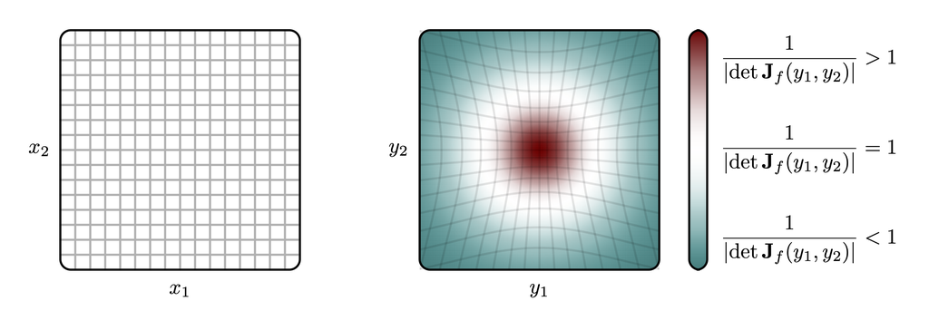

Figure 10: The reciprocal of the absolute value of the Jacobian determinant function, $1 / \mathrm{det} \, \mathbf{J}_{f}(f^{-1}(y))$ is a mouthful. It also quantifies how warped the input Lebesgue measure appears relative to the output Lebesgue measure. If the warping factor is smaller than one, then the input volumes appear to expand. Similarly, if the warping factor is larger than one, then the input volumes appear to contract.

A nearly universal convention in applied probability theory is to ignore the fact that this relationship has to hold for only $\lambda_{Y}$-almost all $y \in Y$ and just take the warping factor to be
$$\frac{ \mathrm{d} f_{*} \lambda_{X} }{ \mathrm{d} \lambda_{Y}}(y)
=
\frac{1}{ | \mathrm{det} \, \mathbf{J}_{f}(f^{-1}(y)) |}.$$
for all output points $y \in Y$.

With this convention, the transformation rule for Lebesgue probability density functions along bijective transformations becomes (Figure 11, Figure 12)
$$\begin{align*}
f_{*} p(y)
&\overset{\lambda_{Y}}{=} p(f^{-1}(y)) \,
\frac{ \mathrm{d} f_{*} \lambda_{X} }{ \mathrm{d} \lambda_{Y}}(y)
\\
&\overset{\lambda_{Y}}{=} p(f^{-1}(y)) \,
\frac{1}{ | \mathrm{det} \, \mathbf{J}_{f}(f^{-1}(y)) | }.
\end{align*}$$

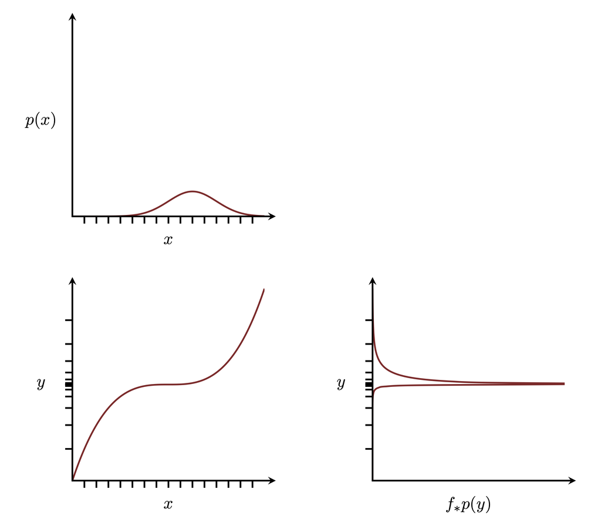

Figure 11: In general, bijective functions from one real space to another warp both probability distributions and reference Lebesgue measures. In order to transform Lebesgue probability density functions, we have to account for both of these changes.

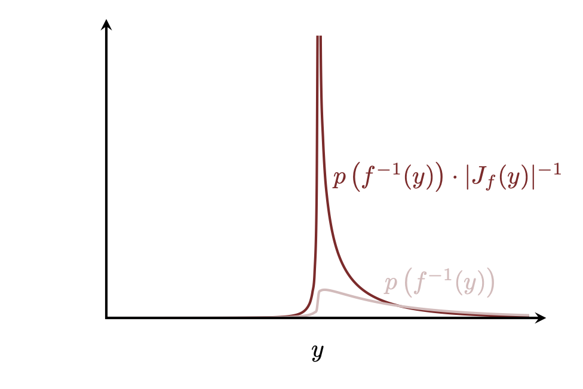

Figure 12: Ignoring the Jacobian correction that accounts for the change in Lebesgue reference measure results in erroneous pushforward probability density functions. This error affects not only the normalization of the pushforward probability density function, but also its shape.

All of this careful work ensures that probability allocations derived from the pushforward Lebesgue probability density function are consistent with the probability allocations derived from the initial Lebesgue probability density function. In particular, we always have (Figure 13)
$$\begin{align*}
\pi( \mathsf{x} ) &= f_{*} \pi ( f_{*} \mathsf{x} )
\\
\mathbb{E}_{\pi} [ I_{\mathsf{x}} ]
&=
\mathbb{E}_{f_{*} \pi} [ I_{f_{*} \mathsf{x}} ]
\\
\mathbb{I}_{\lambda_{X}} [ p \cdot I_{\mathsf{x}} ]
&=
\mathbb{E}_{\lambda_{Y}} [ f_{*} p \cdot I_{f_{*} \mathsf{x}} ]
\\
\int_{\mathbb{R}^{N}} \mathrm{d}^{N} x \,
p(x) \cdot I_{\mathsf{x}}(x)
&=
\int_{\mathbb{R}^{N}} \mathrm{d}^{N} y \,
f_{*} p(y) \cdot I_{f_{*} \mathsf{x}}(y)
\\
\int_{\mathsf{x}} \mathrm{d}^{N} x \, p(x)
&=
\int_{f_{*} \mathsf{x}} \mathrm{d}^{N} y \, f_{*} p(y).
\end{align*}$$

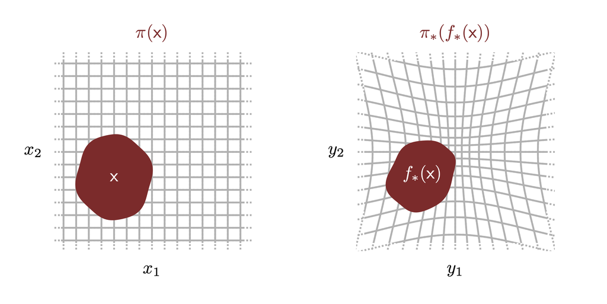

Figure 13: The proper transformation rule for Lebesgue probability density functions allows us to consistently compute probability allocations on the input space and the output space.

When applying the transformation rule for probability density functions in practice, the most common mistake is forgetting the Jacobian correction entirely. The second most common error is forgetting to take the reciprocal of the Jacobian determinant, mistakenly using
$$f_{*} p(y)
\overset{\lambda_{Y}}{=}
p(f^{-1}(y)) \, | \mathrm{det} \, \mathbf{J}_{f}(f^{-1}(y)) |.$$
To avoid this latter mistake, I rely on a mneumonic to help me remember the proper orientation of the Jacobian determinant. I start with the informal integral relationship,
$$\int \mathrm{d} y \, f_{*} p(y) = \int \mathrm{d} x \, p(x),$$
drop the integral signs,
$$\mathrm{d} y \, f_{*} p(y) = \mathrm{d} x \, p(x),$$
and then *very* informally divide by the differentials,
$$\begin{align*}
\mathrm{d} y \, f_{*} p(y) &= \mathrm{d} x \, p(x)
\\
f_{*} p(y)
&=
p(x) \, \frac{ \mathrm{d} x }{ \mathrm{d} y } (x)
\\
f_{*} p(y)
&=
p(x(y)) \, \frac{1}{ \frac{ \mathrm{d} y }{ \mathrm{d} x }(x) }
\\
f_{*} p(y)
&=
p(x) \, \frac{1}{ | \mathrm{det} \, \mathbf{J}_{f}(x) |}
\\
f_{*} p(y)
&=
p(f^{-1}(y)) \, \frac{1}{ | \mathrm{det} \, \mathbf{J}_{f}(f^{-1}(y)) |}.
\end{align*}$$
This is by no means a formal calculation – each step is extremely mathematically sloppy – but the result can be quickly derived and always gives the correct orientation of the Jacobian correction.

Is there anything we can do about non-bijective functions? We might, for instance, be tempted to utilize the Dirac delta function to try to define iterated expectation values on the input space,
$$\begin{align*}
\int_{X} \mathrm{d} x \, \pi(x) \, g(f(x))
&=
\int_{Y} \mathrm{d} y
\left[ \int_{f^{-1}(y)} \mathrm{d} x \, \pi(x) \right] g(y)
\\
&=
\int_{Y} \mathrm{d} y
\left[ \int_{X} \mathrm{d} x \, \pi(x) \delta( f(x) - y ) \right] g(y)
\end{align*}$$
so that
$$f_{*} \pi(y) \overset{\lambda_{Y}}{=}
\int_{X} \mathrm{d} x \, \pi(x) \delta( f(x) - y ).$$
Indeed, this notation is not uncommon in some applied fields.

Unfortunately, it’s not clear how we can actually implement these constrained integrals in practice. In the [next chapter](http://www.symplectomorphic.com/assets/chapters_html/conditional_probability_theory_1.html), we’ll see how we can formalize this strategy using *conditional* expectation values to implement integration over level sets.

### 4.3.2 Examples

After all of that discussion, let’s put these results into practice with a few concrete examples.

#### 4.3.2.1 Translating and Scaling

Consider a probability distribution over a rigid real line, or a fixed parameterization of a flexible real line, specified by a normal probability density function
$$\mathrm{normal}(x; \mu, \sigma)
=
\frac{1}{\sqrt{2 \pi} \sigma}
\exp \left(
-\frac{1}{2} \left( \frac{ x - \mu}{\sigma} \right)^{2}
\right).$$

A translation operator is a function that maps each point in the input real line to a translated point in the output real line,
$$\begin{alignat*}{6}
t_{\delta} :\; & \mathbb{R} & &\rightarrow& \; & \mathbb{R} &
\\
& x & &\mapsto& & x + \delta &.
\end{alignat*}$$
This function is a bijection, with the inverse function translating points in the opposite direction,
$$\begin{alignat*}{6}
t_{\delta}^{-1} :\; & \mathbb{R} & &\rightarrow& \; & \mathbb{R} &
\\
& y & &\mapsto& & y - \delta &.
\end{alignat*}$$

Because the translation operator maps a one-dimensional space into another one-dimensional space, its Jacobian determinant reduces to a single derivative function,
$$\begin{align*}
\mathrm{det} \, \mathbf{J}_{t_{\delta}}(x)
&= \frac{ \mathrm{d} t_{\delta} }{ \mathrm{d} x }(x)
\\
&= \frac{ \mathrm{d} }{ \mathrm{d} x } ( x + \delta )
\\
&= 1.
\end{align*}$$
Consequently, the Jacobian correction is particularly straightforward to calculate,
$$\frac{1}
{| \mathrm{det} \, \mathbf{J}_{t_{\delta}}(t_{\delta}^{-1}(y)) |}
=
\frac{1}{ | 1 | }
=
1.$$

With the Jacobian correction in hand, the pushforward of a normal density function along a translation operator becomes
$$\begin{align*}
(t_{\delta})_{*} \mathrm{normal}(y; \mu, \sigma)
&=
\mathrm{normal}(t_{\delta}^{-1}(y); \mu, \sigma))
\cdot
\frac{1}
{| \mathrm{det} \, \mathbf{J}_{t_{\delta}}(t_{\delta}^{-1}(y)) |}
\\
&=
\mathrm{normal}(y - \delta; \mu, \sigma) \cdot 1
\\
&= \frac{1}{\sqrt{2 \pi} \sigma}
\exp \left(
-\frac{1}{2} \left( \frac{ y - \delta - \mu}{\sigma} \right)^{2}
\right)
\\
&= \frac{1}{\sqrt{2 \pi} \sigma}
\exp \left(
-\frac{1}{2} \left( \frac{ y - (\mu + \delta)}{\sigma} \right)^{2}
\right)
\\
&=
\mathrm{normal}(y; \mu + \delta, \sigma).
\end{align*}$$
In other words, pushing a normal probability density function along a translation operator results in another normal probability density function, only one with a shifted location parameter (Figure 14).

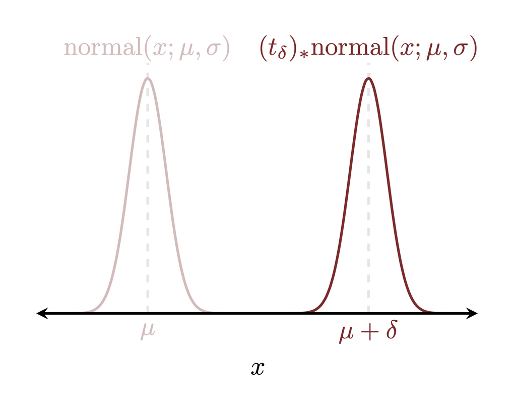

Figure 14: A translation operator $t_{\delta}$ shifts a normal probability density function with location parameter $\mu$ to another normal probability density function with location parameter $\mu + \delta$. The scale parameter $\sigma$ is unaffected.

A scaling operator is a function that maps each point in the input space to a scaled point in the output space,
$$\begin{alignat*}{6}
s_{\phi} :\; & \mathbb{R} & &\rightarrow& \; & \mathbb{R} &
\\
& x & &\mapsto& & \phi \cdot x &
\end{alignat*}$$
for any $\phi > 0$. This is also a bijection, with the inverse function scaling points by the reciprocal of $\phi$,
$$\begin{alignat*}{6}
s_{\phi}^{-1} :\; & \mathbb{R} & &\rightarrow& \; & \mathbb{R} &
\\
& y & &\mapsto& & \frac{y}{\phi} &.
\end{alignat*}$$

The Jacobian determinant once again reduces to just a single derivative function,
$$\begin{align*}
\mathrm{det} \, \mathbf{J}_{s_{\phi}}(x)
&= \frac{ \mathrm{d} s_{\phi} }{ \mathrm{d} x }(x)
\\
&= \frac{ \mathrm{d} }{ \mathrm{d} x } ( \phi \cdot x )
\\
&= \phi
\end{align*}$$
In this case, the Jacobian correction is slightly more complicated,
$$\frac{1}{| \mathrm{det} \, \mathbf{J}_{s_{\phi}}(s_{\phi}^{-1}(y)) |}
=
\frac{1}{ | \phi | }
=
\frac{1}{ \phi }.$$

The pushforward of a normal density function along a scaling operator is then given by
$$\begin{align*}
(s_{\phi})_{*} \mathrm{normal}(y; \mu, \sigma)
&=
\mathrm{normal}(s_{\phi}^{-1}(y); \mu, \sigma))
\cdot
\frac{1}
{| \mathrm{det} \, \mathbf{J}_{s_{\phi}}(s_{\phi}^{-1}(y)) |}
\\
&=
\mathrm{normal}( y / \phi; \mu, \sigma) \frac{1}{\phi}
\\
&= \frac{1}{\sqrt{2 \pi} \sigma} \cdot \frac{1}{\phi} \,
\exp \left(
-\frac{1}{2} \left( \frac{ y / \phi - \mu}{\sigma} \right)^{2}
\right)
\\
&= \frac{1}{\sqrt{2 \pi} (\phi \cdot \sigma)}
\exp \left(
-\frac{1}{2}
\left( \frac{ y - \phi \cdot \mu}{\phi \cdot \sigma} \right)^{2}
\right)
\\
&=
\mathrm{normal}(y; \phi \cdot \mu, \phi \cdot \sigma).
\end{align*}$$
As before, pushing a normal probability density function along a scaling operator results in another normal probability density function. In this case, however, both the location and scale parameters are affected (Figure 15).

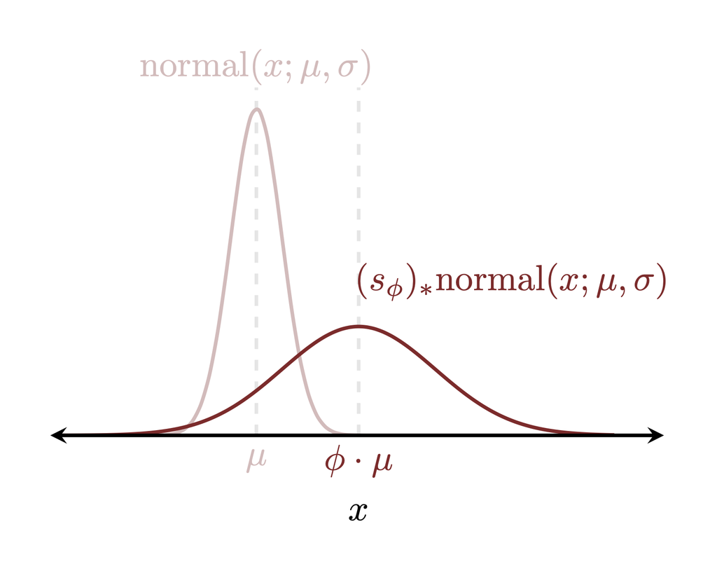

Figure 15: A scale operator $s_{\phi}$ transforms a normal probability density function with location parameter $\mu$ and scale parameter $\sigma$ into normal probability density function with the inflated location parameter $\phi \cdot \mu$ and inflated scale parameter $\phi \cdot \sigma$.

These two operations can also be combined into a single function that first scales and then translates,
$$st_{\delta, \phi} = t_{\delta} \circ s_{\phi}$$
with
$$\begin{alignat*}{6}
st_{\delta, \phi} :\; & \mathbb{R} & &\rightarrow& \; & \mathbb{R} &
\\
& x & &\mapsto& & \phi \cdot x + \delta &.
\end{alignat*}$$
This composition defines another bijection, with the inverse function scaling points by the reciprocal of the scaling parameter before translating in the opposite direction,
$$st_{\delta, \phi}^{-1} = s_{\phi}^{-1} \circ t_{\delta}^{-1}$$
with
$$\begin{alignat*}{6}
st_{\delta, \phi}^{-1} :\; & \mathbb{R} & &\rightarrow& \; & \mathbb{R} &
\\
& y & &\mapsto& & \frac{y - \delta}{\phi} &.
\end{alignat*}$$

The Jacobian determinant for this composition is
$$\begin{align*}
\mathrm{det} \, \mathbf{J}_{st_{\delta, \phi}}(x)
&= \frac{ \mathrm{d} st_{\delta, \phi} }{ \mathrm{d} x }(x)
\\
&= \frac{ \mathrm{d} }{ \mathrm{d} x } ( \phi \cdot x + \delta )
\\
&= \phi,
\end{align*}$$
with the Jacobian correction becoming
$$\frac{1}
{| \mathrm{det} \, \mathbf{J}_{st_{\delta, \phi}}
(st_{\delta, \phi}^{-1}(y)) |}
=
\frac{1}{ | \phi | }
=
\frac{1}{ \phi }.$$

Pushing a normal probability density function forward along this composite function gives
$$\begin{align*}
(st_{\delta, \phi})_{*} \mathrm{normal}(y; \mu, \sigma)
&=
\mathrm{normal}(st_{\delta, \phi}^{-1}(y); \mu, \sigma)
\cdot
\frac{1}
{|
\mathrm{det} \, \mathbf{J}_{st_{\delta, \phi}}(s_{\phi}^{-1}(y))
|}
\\
&=
\mathrm{normal}( (y - \delta) / \phi ; \mu, \sigma) \cdot (1 / \phi)
\\
&= \frac{1}{\sqrt{2 \pi} \sigma} \frac{1}{ \phi }
\exp \left(
-\frac{1}{2}
\left( \frac{ (y - \delta) / \phi - \mu}{\sigma} \right)^{2}
\right)
\\
&= \frac{1}{\sqrt{2 \pi} (\phi \cdot \sigma)}
\exp \left(
-\frac{1}{2}
\left(
\frac{ y - (\phi \cdot \mu + \delta)}{\phi \cdot \sigma}
\right)^{2}
\right)
\\
&=
\mathrm{normal}(y; \phi \cdot \mu + \delta, \phi \cdot \sigma).
\end{align*}$$
No matter how we scale and translate an ambient real line, a normal probability density function will always map into another normal probability density function.

In fact, if we start with the **unit normal probability density function**
$$\text{unit-normal}(x) = \text{normal}(x; 0, 1),$$
then the pushforward probability density function along the scale-translation function becomes
$$(st_{\delta, \phi})_{*} \text{unit-normal}(y)
=
\mathrm{normal}(y; \delta, \phi).$$
In other words, we can generate *every* normal probability density function from a suitable transformation of a unit normal probability density function. Consequently, the normal family of probability density functions is known as a **location-scale** family.

#### 4.3.2.2 Squeezing A Real Line Into An Interval

For a more sophisticated example, let’s look at the logistic function that we introduced in Section 2.1,
$$\begin{alignat*}{6}
\text{logistic} :\; & \mathbb{R} & &\rightarrow& \; & (0, 1) &
\\
& x & &\mapsto& & \frac{1}{1 + \exp(-x)} &.
\end{alignat*}$$
The logistic function is bijective and its inverse function is known as the **logit function**,
$$\begin{alignat*}{6}
\text{logit} :\; & (0, 1) & &\rightarrow& \; & \mathbb{R} &
\\
& y & &\mapsto& & \log \frac{y}{1 - y} &.
\end{alignat*}$$

The pushforward of a normal density function along the logistic function is given by (Figure 16)
$$\begin{align*}
\text{logistic}_{*} \mathrm{normal}(y; \mu, \sigma)
&=
\mathrm{normal}( \text{logit}(y); \mu, \sigma)
\cdot \frac{1}
{| \mathrm{det} \, \mathbf{J}_{\text{logistic}}(\text{logit}(y)) |}
\\
&=
\mathrm{normal}( \text{logit}(y); \mu, \sigma) \frac{1}{y(1 - y)}.
\end{align*}$$

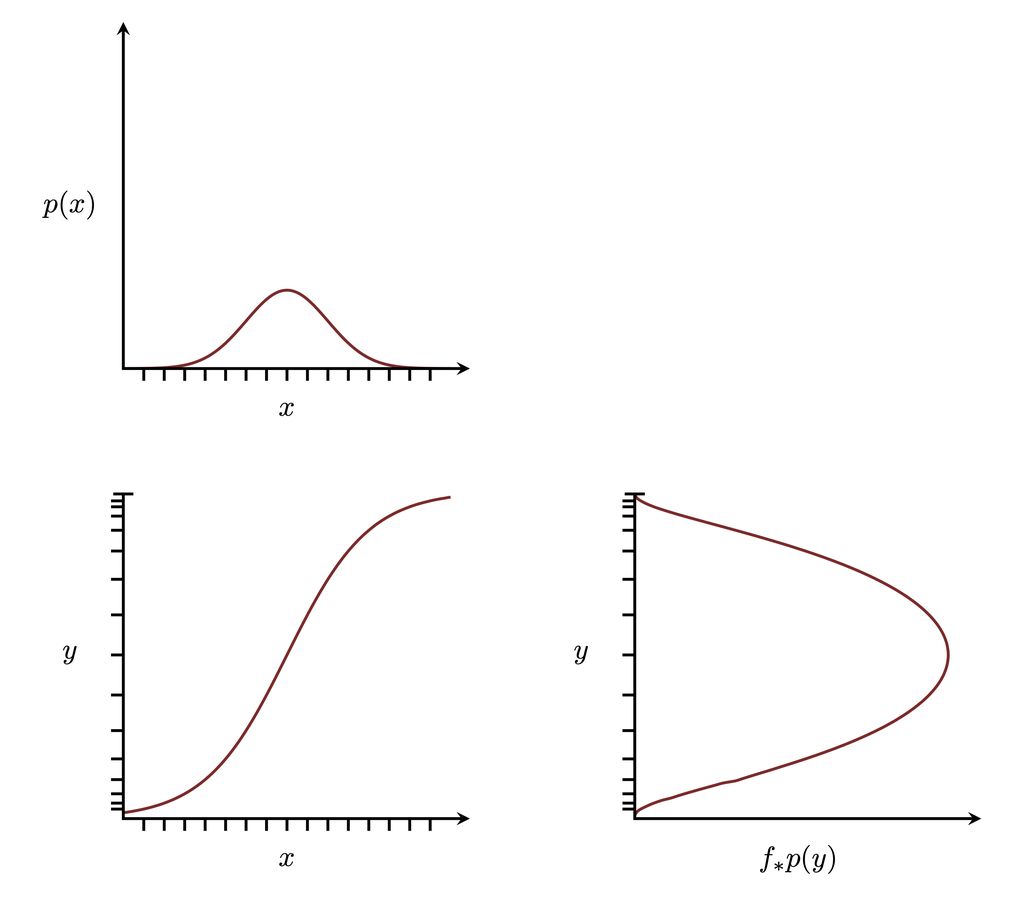

Figure 16: The logistic function squeezes a real line into a unit interval, transforming Lebesgue probability density functions over all real numbers into a Lebesgue probability density function over real numbers $0 < y < 1$.

# 5 Characterizing One-Dimensional Pushforward Probability Distributions

Probability distributions on high-dimensional spaces are overwhelming objects that are typically too difficult to study directly. For example, we cannot convey the entirety of a high-dimensional probability distribution in a single visualization.

We can, however, explore high-dimensional behavior by examining multiple low-dimensional summaries, not unlike a carpenter checking if a piece of wood is warped by staring down each edge one at a time (Figure 17). More formally, we can push a high-dimensional probability distribution forward to many one-dimensional probability distributions that can be neatly visualized.

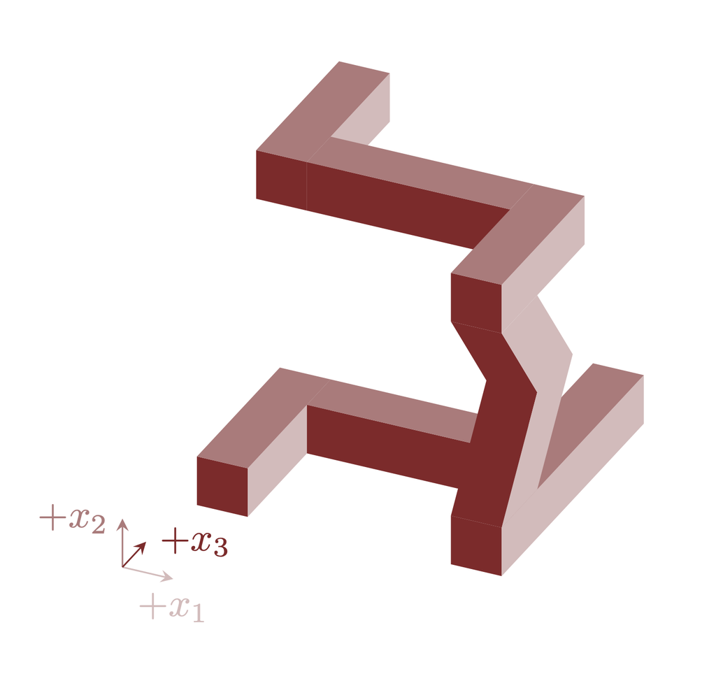

(a)

[figure not shown]

(b)

Figure 17: In general, (a) high-dimensional mathematical objects, such probability distributions over high-dimensional spaces, are difficult to interpret directly. (b) Summary functions map high-dimensional objects to low-dimensional objects, isolating behaviors that can be not only easier to digest but also straightforward to visualize.

Given a probability space $(X, \mathcal{X}, \pi)$ and a collection of measurable functions
$$f_{n} : (X, \mathcal{X}) \rightarrow
(\mathbb{R}, \mathcal{B}_{\mathbb{R}}),$$
we can construct a collection of one-dimensional pushforward probability distributions
$$(f_{n})_{*} \pi.$$
Each of these pushforward probability distributions summarizes a different aspect of $\pi$; the more interpretable the outputs of the summary function $f_{n}$ are, the more interpretable the corresponding pushforward distribution will be.

In order to implementing these probabilistic summaries in practice, however, we need to be able to characterize the pushforward probability distributions. Pushforward probability density functions would be particularly convenient for visualization (Figure 18), but at this point we don’t know how to actually compute them yet for non-bijective summary functions. Unfortunately, in the [next chapter](http://www.symplectomorphic.com/assets/chapters_html/conditional_probability_theory_1.html) we’ll see that the necessary operations are often infeasible in practice.

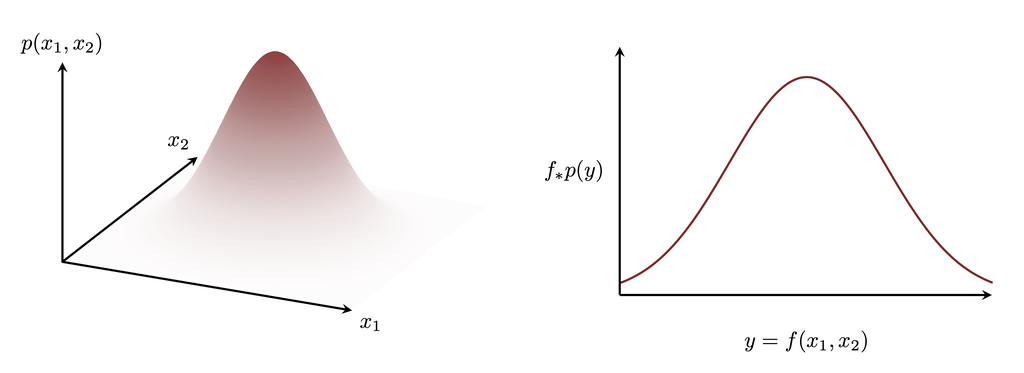

Figure 18: A pushforward probability density function is particularly useful for visualizing pushforward behavior extracted from a high-dimensional input probability distribution. Frustratingly, they often infeasible to construct in practice.

That said, in [Chapter Five](http://www.symplectomorphic.com/assets/chapters_html/expectation_values.html) we learned multiple ways to characterize one-dimensional probability distributions using only expectation values. If we can compute expectation values on the initial, high-dimensional ambient space, then we can use the pullback of expectation values,
$$\mathbb{E}_{f_{*} \pi}[ g ] = \mathbb{E}_{\pi} [ g \circ f ].$$
to implement these expectation-based characterizations in practice.

For instance, in Section 3 we saw that the moments of one-dimensional pushforward distributions can be evaluated as expectation values over the initial space. In particular, we can compute the mean and variance of the pushfoward probability distribution $(f_{n})_{*} \pi$ by evaluating the expectation values
$$\mathbb{M}_{(f_{n})_{*} \pi}
=
\mathbb{E}_{\pi} [ f_{n} ]$$
and
$$\mathbb{V}_{f^{*} \mu}
=
\mathbb{E}_{(f_{n})_{*} \pi} [
(f - \mathbb{M}_{(f_{n})_{*} \pi})^{2}
],$$
respectively. That is, of course, provided that both expectands are integrable.